# Predicting Bike Shares Demand with Ridge and Lasso

Jehangeer!

2023-09-15

# About Data Analysis Report

**Data Description:**

**Data Source:** https://www.kaggle.com/datasets/marklvl/bike-sharing-dataset

**Relevant Paper:**

Fanaee-T, Hadi, and Gama, Joao, ‘Event labeling combining ensemble detectors and background knowledge’, Progress in Artificial Intelligence (2013): pp. 1-15, Springer Berlin Heidelberg

# Load and explore the data

## Load data and install packages

```r
## Importing required packages

# install.packages("tidyverse")
# install.packages("tidymodels")

library(tidyverse)
library(tidymodels)
bikes_hours <- read_csv("bike-sharing-dataset/hour.csv")
glimpse(bikes_hours)
```

```
## Rows: 17,379
## Columns: 17
## $ instant    <dbl> 1, 2, 3, 4, 5, 6, 7, 8, 9, 10, 11, 12, 13, 14, 15, 16, 17, …
## $ dteday     <date> 2011-01-01, 2011-01-01, 2011-01-01, 2011-01-01, 2011-01-01…
## $ season     <dbl> 1, 1, 1, 1, 1, 1, 1, 1, 1, 1, 1, 1, 1, 1, 1, 1, 1, 1, 1, 1,…
## $ yr         <dbl> 0, 0, 0, 0, 0, 0, 0, 0, 0, 0, 0, 0, 0, 0, 0, 0, 0, 0, 0, 0,…
## $ mnth       <dbl> 1, 1, 1, 1, 1, 1, 1, 1, 1, 1, 1, 1, 1, 1, 1, 1, 1, 1, 1, 1,…
## $ hr         <dbl> 0, 1, 2, 3, 4, 5, 6, 7, 8, 9, 10, 11, 12, 13, 14, 15, 16, 1…
## $ holiday    <dbl> 0, 0, 0, 0, 0, 0, 0, 0, 0, 0, 0, 0, 0, 0, 0, 0, 0, 0, 0, 0,…
## $ weekday    <dbl> 6, 6, 6, 6, 6, 6, 6, 6, 6, 6, 6, 6, 6, 6, 6, 6, 6, 6, 6, 6,…
## $ workingday <dbl> 0, 0, 0, 0, 0, 0, 0, 0, 0, 0, 0, 0, 0, 0, 0, 0, 0, 0, 0, 0,…
## $ weathersit <dbl> 1, 1, 1, 1, 1, 2, 1, 1, 1, 1, 1, 1, 1, 2, 2, 2, 2, 2, 3, 3,…
## $ temp       <dbl> 0.24, 0.22, 0.22, 0.24, 0.24, 0.24, 0.22, 0.20, 0.24, 0.32,…
## $ atemp      <dbl> 0.2879, 0.2727, 0.2727, 0.2879, 0.2879, 0.2576, 0.2727, 0.2…
## $ hum        <dbl> 0.81, 0.80, 0.80, 0.75, 0.75, 0.75, 0.80, 0.86, 0.75, 0.76,…
## $ windspeed  <dbl> 0.0000, 0.0000, 0.0000, 0.0000, 0.0000, 0.0896, 0.0000, 0.0…
## $ casual     <dbl> 3, 8, 5, 3, 0, 0, 2, 1, 1, 8, 12, 26, 29, 47, 35, 40, 41, 1…
## $ registered <dbl> 13, 32, 27, 10, 1, 1, 0, 2, 7, 6, 24, 30, 55, 47, 71, 70, 5…
## $ cnt        <dbl> 16, 40, 32, 13, 1, 1, 2, 3, 8, 14, 36, 56, 84, 94, 106, 110…
```

```r
# theme set

theme_set(theme_minimal(base_size = 12, base_family = "Open Sans"))
```

## Which factors contribute to bike rental demand?

Here are the objectives of doing the advanced analysis on bike rental demand:

Attain superior accuracy in predicting bike rental demand.

Investigate whether a noteworthy correlation exists between the season and the bike rental demand.

Gain insights into how bike rental demand varies across different time segments within a day.

Determine the relationship between bike rental demand and prevailing weather conditions.

## Describe and explore the data

```r
# first six observations of the datasets

head(bikes_hours)
```

```
## # A tibble: 6 × 17
##   instant dteday     season    yr  mnth    hr holiday weekday workingday
##     <dbl> <date>      <dbl> <dbl> <dbl> <dbl>   <dbl>   <dbl>      <dbl>
## 1       1 2011-01-01      1     0     1     0       0       6          0
## 2       2 2011-01-01      1     0     1     1       0       6          0
## 3       3 2011-01-01      1     0     1     2       0       6          0
## 4       4 2011-01-01      1     0     1     3       0       6          0
## 5       5 2011-01-01      1     0     1     4       0       6          0
## 6       6 2011-01-01      1     0     1     5       0       6          0
## # ℹ 8 more variables: weathersit <dbl>, temp <dbl>, atemp <dbl>, hum <dbl>,
## #   windspeed <dbl>, casual <dbl>, registered <dbl>, cnt <dbl>
```

```r
# checking missing values
sum(is.na(bikes_hours))
```

```
## [1] 0
```

```r
# summary statistics
summary(bikes_hours)
```

```
##     instant          dteday               season            yr
##  Min.   :    1   Min.   :2011-01-01   Min.   :1.000   Min.   :0.0000
##  1st Qu.: 4346   1st Qu.:2011-07-04   1st Qu.:2.000   1st Qu.:0.0000
##  Median : 8690   Median :2012-01-02   Median :3.000   Median :1.0000
##  Mean   : 8690   Mean   :2012-01-02   Mean   :2.502   Mean   :0.5026
##  3rd Qu.:13034   3rd Qu.:2012-07-02   3rd Qu.:3.000   3rd Qu.:1.0000
##  Max.   :17379   Max.   :2012-12-31   Max.   :4.000   Max.   :1.0000
##       mnth              hr           holiday           weekday
##  Min.   : 1.000   Min.   : 0.00   Min.   :0.00000   Min.   :0.000
##  1st Qu.: 4.000   1st Qu.: 6.00   1st Qu.:0.00000   1st Qu.:1.000
##  Median : 7.000   Median :12.00   Median :0.00000   Median :3.000
##  Mean   : 6.538   Mean   :11.55   Mean   :0.02877   Mean   :3.004
##  3rd Qu.:10.000   3rd Qu.:18.00   3rd Qu.:0.00000   3rd Qu.:5.000
##  Max.   :12.000   Max.   :23.00   Max.   :1.00000   Max.   :6.000
##    workingday       weathersit         temp           atemp
##  Min.   :0.0000   Min.   :1.000   Min.   :0.020   Min.   :0.0000
##  1st Qu.:0.0000   1st Qu.:1.000   1st Qu.:0.340   1st Qu.:0.3333
##  Median :1.0000   Median :1.000   Median :0.500   Median :0.4848
##  Mean   :0.6827   Mean   :1.425   Mean   :0.497   Mean   :0.4758
##  3rd Qu.:1.0000   3rd Qu.:2.000   3rd Qu.:0.660   3rd Qu.:0.6212
##  Max.   :1.0000   Max.   :4.000   Max.   :1.000   Max.   :1.0000
##       hum           windspeed          casual         registered
##  Min.   :0.0000   Min.   :0.0000   Min.   :  0.00   Min.   :  0.0
##  1st Qu.:0.4800   1st Qu.:0.1045   1st Qu.:  4.00   1st Qu.: 34.0
##  Median :0.6300   Median :0.1940   Median : 17.00   Median :115.0
##  Mean   :0.6272   Mean   :0.1901   Mean   : 35.68   Mean   :153.8
##  3rd Qu.:0.7800   3rd Qu.:0.2537   3rd Qu.: 48.00   3rd Qu.:220.0
##  Max.   :1.0000   Max.   :0.8507   Max.   :367.00   Max.   :886.0
##       cnt
##  Min.   :  1.0
##  1st Qu.: 40.0
##  Median :142.0
##  Mean   :189.5
##  3rd Qu.:281.0
##  Max.   :977.0
```

Here, a distinct dataframe is established to maintain data integrity, enabling easy adjustments without reloading the original dataset. This new dataframe excludes ‘instant’ and ‘dteday’ variables, as they hold no predictive value.

```r
# Constructing a 'bike_data' dataframe with organized data attributes

bike_data <-  data.frame(count = bikes_hours$cnt,
                         season = as.factor(bikes_hours$season),
                         year = as.factor(bikes_hours$yr),
                         month = as.factor(bikes_hours$mnth),
                         hour = as.factor(bikes_hours$hr),
                         holi = as.factor(bikes_hours$holiday),
                         week = as.factor(bikes_hours$weekday),
                         work = as.factor(bikes_hours$workingday),
                         weather = as.factor(bikes_hours$weathersit),
                         env.temp = bikes_hours$temp,
                         feel.temp = bikes_hours$atemp,
                         humidity = bikes_hours$hum,
                         windspeed = bikes_hours$windspeed,
                         registered = bikes_hours$registered,
                         casual = bikes_hours$casual)

# Column names
names(bike_data)
```

```
##  [1] "count"      "season"     "year"       "month"      "hour"
##  [6] "holi"       "week"       "work"       "weather"    "env.temp"
## [11] "feel.temp"  "humidity"   "windspeed"  "registered" "casual"
```

```r
# Glimpse of new data
glimpse(bike_data)
```

```
## Rows: 17,379
## Columns: 15
## $ count      <dbl> 16, 40, 32, 13, 1, 1, 2, 3, 8, 14, 36, 56, 84, 94, 106, 110…
## $ season     <fct> 1, 1, 1, 1, 1, 1, 1, 1, 1, 1, 1, 1, 1, 1, 1, 1, 1, 1, 1, 1,…
## $ year       <fct> 0, 0, 0, 0, 0, 0, 0, 0, 0, 0, 0, 0, 0, 0, 0, 0, 0, 0, 0, 0,…
## $ month      <fct> 1, 1, 1, 1, 1, 1, 1, 1, 1, 1, 1, 1, 1, 1, 1, 1, 1, 1, 1, 1,…
## $ hour       <fct> 0, 1, 2, 3, 4, 5, 6, 7, 8, 9, 10, 11, 12, 13, 14, 15, 16, 1…
## $ holi       <fct> 0, 0, 0, 0, 0, 0, 0, 0, 0, 0, 0, 0, 0, 0, 0, 0, 0, 0, 0, 0,…
## $ week       <fct> 6, 6, 6, 6, 6, 6, 6, 6, 6, 6, 6, 6, 6, 6, 6, 6, 6, 6, 6, 6,…
## $ work       <fct> 0, 0, 0, 0, 0, 0, 0, 0, 0, 0, 0, 0, 0, 0, 0, 0, 0, 0, 0, 0,…
## $ weather    <fct> 1, 1, 1, 1, 1, 2, 1, 1, 1, 1, 1, 1, 1, 2, 2, 2, 2, 2, 3, 3,…
## $ env.temp   <dbl> 0.24, 0.22, 0.22, 0.24, 0.24, 0.24, 0.22, 0.20, 0.24, 0.32,…
## $ feel.temp  <dbl> 0.2879, 0.2727, 0.2727, 0.2879, 0.2879, 0.2576, 0.2727, 0.2…
## $ humidity   <dbl> 0.81, 0.80, 0.80, 0.75, 0.75, 0.75, 0.80, 0.86, 0.75, 0.76,…
## $ windspeed  <dbl> 0.0000, 0.0000, 0.0000, 0.0000, 0.0000, 0.0896, 0.0000, 0.0…
## $ registered <dbl> 13, 32, 27, 10, 1, 1, 0, 2, 7, 6, 24, 30, 55, 47, 71, 70, 5…
## $ casual     <dbl> 3, 8, 5, 3, 0, 0, 2, 1, 1, 8, 12, 26, 29, 47, 35, 40, 41, 1…
```

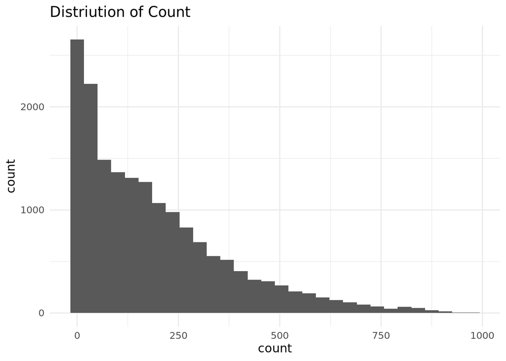

```r
# Distribution of response variable.

bike_data |>
  ggplot(aes(x = count)) +
  geom_histogram() +
  labs(title = "Distriution of Count")
```

We are considering the use of a Poisson regression model because our response variable consists of discrete numeric values, although they are no any non-negative integers, and response variable follows poisson distribution.

```r
# Fit a Poisson regression model
poisson_model <- glm(count ~ .,
             data = bike_data,
             family = "poisson")

summary(poisson_model)
```

```
##
## Call:
## glm(formula = count ~ ., family = "poisson", data = bike_data)
##
## Coefficients: (1 not defined because of singularities)
##               Estimate Std. Error  z value Pr(>|z|)
## (Intercept)  3.441e+00  6.836e-03  503.310  < 2e-16 ***
## season2      1.048e-01  3.720e-03   28.180  < 2e-16 ***
## season3      1.606e-01  4.259e-03   37.697  < 2e-16 ***
## season4      2.298e-01  4.169e-03   55.123  < 2e-16 ***
## year1        8.251e-02  1.365e-03   60.444  < 2e-16 ***
## month2       8.652e-02  3.777e-03   22.909  < 2e-16 ***
## month3       9.616e-02  3.957e-03   24.301  < 2e-16 ***
## month4       8.231e-02  5.273e-03   15.610  < 2e-16 ***
## month5       1.036e-01  5.509e-03   18.807  < 2e-16 ***
## month6       6.576e-02  5.610e-03   11.722  < 2e-16 ***
## month7       3.222e-03  6.104e-03    0.528 0.597599
## month8       7.157e-03  5.958e-03    1.201 0.229697
## month9      -1.393e-02  5.507e-03   -2.530 0.011402 *
## month10     -2.049e-02  5.485e-03   -3.736 0.000187 ***
## month11      2.762e-02  5.367e-03    5.146 2.66e-07 ***
## month12      1.373e-02  4.759e-03    2.886 0.003907 **
## hour1       -4.154e-01  8.183e-03  -50.761  < 2e-16 ***
## hour2       -7.613e-01  9.314e-03  -81.736  < 2e-16 ***
## hour3       -1.399e+00  1.216e-02 -114.993  < 2e-16 ***
## hour4       -1.993e+00  1.586e-02 -125.650  < 2e-16 ***
## hour5       -8.849e-01  9.788e-03  -90.409  < 2e-16 ***
## hour6        2.979e-01  6.622e-03   44.988  < 2e-16 ***
## hour7        8.687e-01  5.788e-03  150.104  < 2e-16 ***
## hour8        8.948e-01  5.864e-03  152.609  < 2e-16 ***
## hour9        9.288e-01  5.704e-03  162.826  < 2e-16 ***
## hour10       7.892e-01  5.838e-03  135.179  < 2e-16 ***
## hour11       8.379e-01  5.779e-03  145.000  < 2e-16 ***
## hour12       8.878e-01  5.745e-03  154.526  < 2e-16 ***
## hour13       8.767e-01  5.774e-03  151.831  < 2e-16 ***
## hour14       8.572e-01  5.816e-03  147.375  < 2e-16 ***
## hour15       8.786e-01  5.799e-03  151.504  < 2e-16 ***
## hour16       9.379e-01  5.726e-03  163.807  < 2e-16 ***
## hour17       8.252e-01  5.898e-03  139.920  < 2e-16 ***
## hour18       8.559e-01  5.845e-03  146.430  < 2e-16 ***
```

[output cut: 17 more lines]

```
## feel.temp    4.779e-01  1.956e-02   24.432  < 2e-16 ***
## humidity     9.002e-04  4.199e-03    0.214 0.830265
## windspeed   -4.473e-02  4.926e-03   -9.081  < 2e-16 ***
## registered   2.599e-03  5.773e-06  450.162  < 2e-16 ***
## casual       2.805e-03  1.517e-05  184.926  < 2e-16 ***
## ---
## Signif. codes:  0 '***' 0.001 '**' 0.01 '*' 0.05 '.' 0.1 ' ' 1
##
## (Dispersion parameter for poisson family taken to be 1)
##
##     Null deviance: 2891591  on 17378  degrees of freedom
## Residual deviance:  220933  on 17324  degrees of freedom
## AIC: 331943
##
## Number of Fisher Scoring iterations: 5
```

```r
# Checking over dispersion

# install.packages("AER")

library(AER)
dispersion_test <- dispersiontest(poisson_model)
print(dispersion_test)
```

```
##
##  Overdispersion test
##
## data:  poisson_model
## z = 72.187, p-value < 2.2e-16
## alternative hypothesis: true dispersion is greater than 1
## sample estimates:
## dispersion
##   11.97053
```

The p-value is very close to zero (p-value < 2.2e-16), indicating that the true dispersion is significantly greater than 1.

Based on these results, we should consider using an alternative modeling approach that can account for over dispersion.

Negative Binomial Regression: This model is suitable for count data with overdispersion and can be a good choice in this situation.

```r
# install.packages("MASS")

library(MASS)
model_nb <- glm.nb(count ~ ., data = bike_data)

summary(model_nb)
```

```
##
## Call:
## glm.nb(formula = count ~ ., data = bike_data, init.theta = 6.870894767,
##     link = log)
##
## Coefficients: (1 not defined because of singularities)
##               Estimate Std. Error z value Pr(>|z|)
## (Intercept)  3.285e+00  2.683e-02 122.444  < 2e-16 ***
## season2      1.319e-01  1.939e-02   6.800 1.04e-11 ***
## season3      1.845e-01  2.285e-02   8.077 6.66e-16 ***
## season4      2.636e-01  1.975e-02  13.350  < 2e-16 ***
## year1        1.316e-01  6.806e-03  19.337  < 2e-16 ***
## month2       6.744e-02  1.584e-02   4.257 2.07e-05 ***
## month3       8.890e-02  1.777e-02   5.004 5.63e-07 ***
## month4       6.197e-02  2.619e-02   2.366 0.017995 *
## month5       1.270e-01  2.798e-02   4.538 5.68e-06 ***
## month6       6.411e-02  2.875e-02   2.230 0.025770 *
## month7       1.570e-02  3.213e-02   0.489 0.625088
## month8       1.252e-02  3.132e-02   0.400 0.689207
## month9       3.048e-02  2.791e-02   1.092 0.274827
## month10      4.694e-03  2.600e-02   0.181 0.856757
## month11     -7.125e-03  2.504e-02  -0.285 0.775952
## month12     -2.120e-02  2.005e-02  -1.057 0.290428
## hour1       -4.164e-01  2.202e-02 -18.913  < 2e-16 ***
## hour2       -7.461e-01  2.261e-02 -33.000  < 2e-16 ***
## hour3       -1.316e+00  2.411e-02 -54.603  < 2e-16 ***
## hour4       -1.841e+00  2.610e-02 -70.530  < 2e-16 ***
## hour5       -7.417e-01  2.265e-02 -32.752  < 2e-16 ***
## hour6        3.036e-01  2.143e-02  14.167  < 2e-16 ***
## hour7        6.355e-01  2.198e-02  28.917  < 2e-16 ***
## hour8        6.434e-01  2.368e-02  27.169  < 2e-16 ***
## hour9        8.649e-01  2.161e-02  40.013  < 2e-16 ***
## hour10       7.836e-01  2.146e-02  36.515  < 2e-16 ***
## hour11       8.264e-01  2.176e-02  37.974  < 2e-16 ***
## hour12       8.672e-01  2.214e-02  39.162  < 2e-16 ***
## hour13       8.660e-01  2.229e-02  38.845  < 2e-16 ***
## hour14       8.581e-01  2.239e-02  38.319  < 2e-16 ***
## hour15       8.668e-01  2.244e-02  38.620  < 2e-16 ***
## hour16       8.722e-01  2.272e-02  38.392  < 2e-16 ***
## hour17       7.224e-01  2.445e-02  29.549  < 2e-16 ***
```

[output cut: 24 more lines]

```
## Signif. codes:  0 '***' 0.001 '**' 0.01 '*' 0.05 '.' 0.1 ' ' 1
##
## (Dispersion parameter for Negative Binomial(6.8709) family taken to be 1)
##
##     Null deviance: 148543  on 17378  degrees of freedom
## Residual deviance:  19653  on 17324  degrees of freedom
## AIC: 179577
##
## Number of Fisher Scoring iterations: 1
##
##
##               Theta:  6.8709
##           Std. Err.:  0.0891
##
##  2 x log-likelihood:  -179465.1100
```

```r
# Calculating the AIC
aic_value <- AIC(model_nb)

# AIC value
aic_value
```

```
## [1] 179577.1
```

The model’s AIC value of approximately 179,577.1 indicates a reasonable trade-off between goodness of fit and model complexity, suggesting its suitability for predicting bike rentals. However, further model refinement and evaluation against alternative models may be necessary to optimize performance.